# Reproducible Research Week 2 Project (Shilp Shah)

```r
library(ggplot2)
```

First, let’s read in the data

```r
data <- read.csv("activity.csv")
```

Now, we’re going to find the total numbers of steps per day and clean up output

```r
total_steps <- aggregate(x=data$steps, FUN = sum, by = list(data$date))
total_steps <- total_steps[complete.cases(total_steps),]
colnames(total_steps) <- c("Date","Total Steps")
```

Let’s create a Histogram of the total number of steps per day

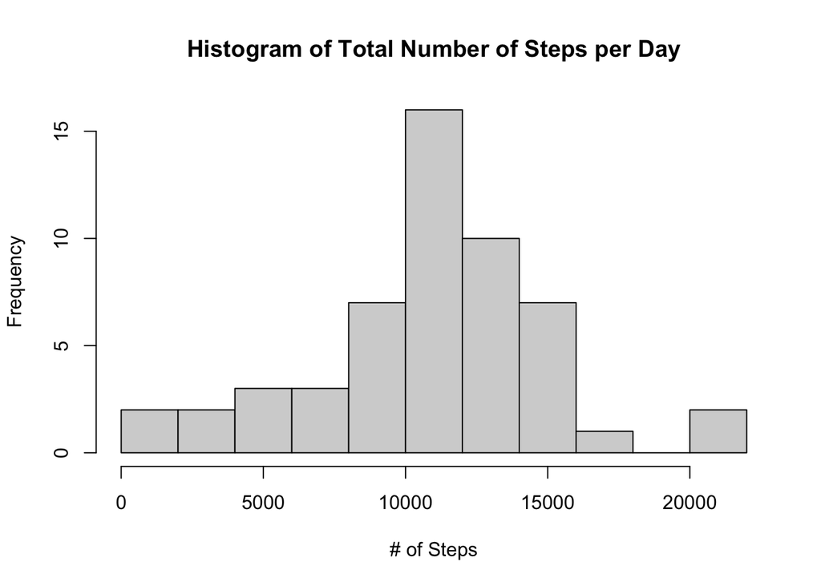

```r
hist(total_steps$`Total Steps`,breaks = 10, xlab = "# of Steps",
     main = "Histogram of Total Number of Steps per Day")
```

And also calculate the mean and median of the total number of steps taken per day

```r
mean(total_steps$`Total Steps`)
```

[1] 10766.19

```r
median(total_steps$`Total Steps`)
```

[1] 10765

Now, we are going to calculate the average number of steps taken for each time period across all of the days, and then plot the data with a line graph

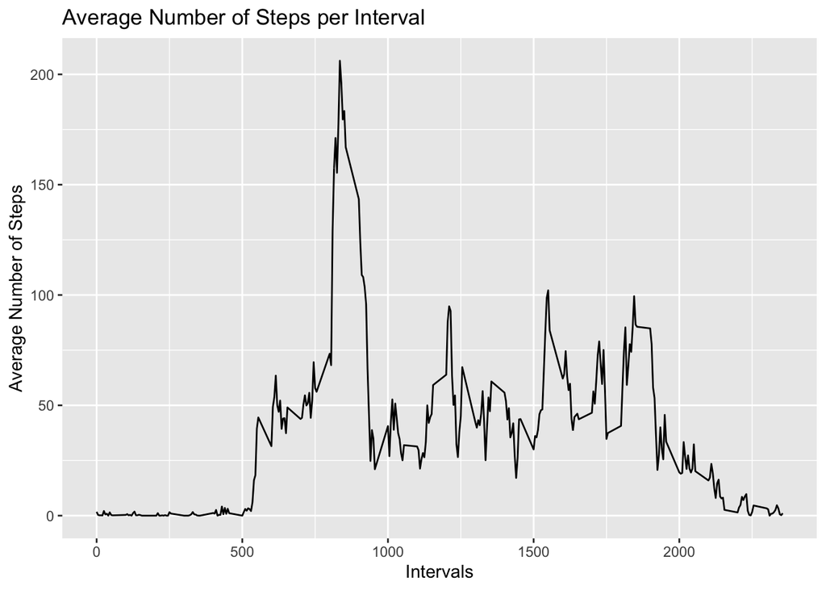

```r
interval_steps <- aggregate(x=data$steps, FUN = mean, by = list(data$interval),
                            na.rm = T)
colnames(interval_steps) <- c("Interval","Average Steps")
ggplot(data = interval_steps, aes(Interval, `Average Steps`)) + geom_line() +
        xlab("Intervals") + ylab("Average Number of Steps") +
        ggtitle("Average Number of Steps per Interval")
```

And next, we will find which time period contains the maximum average number of steps

```r
max_avg <- max(interval_steps$`Average Steps`)
t_avg <- (interval_steps$`Average Steps`== max_avg)
max_int <- interval_steps$Interval[t_avg]
max_int
```

```
## [1] 835
```

The data we were given contains many missing values, with even some days that have all missing values. So we will be putting in the average number of steps for 5-minute intervals for one day in the place of these missing values.

```r
##First, we're going to find out how many missing values this data set contains.
total_na <- sum(is.na(data))
total_na
```

```
## [1] 2304
```

```r
##Second we're finding the average number of steps per day
avg_day <- sum(data$steps, na.rm = T)/nrow(as.data.frame(unique(data$date)))
avg_day
```

```
## [1] 9354.23
```

```r
##Then we're going to divide by the number of intervals to get an average
##number of steps per interval
avg_overall <- avg_day/nrow(interval_steps)
avg_overall
```

```
## [1] 32.47996
```

Here we are going to replace all of the missing data in the data set with the average value we found, and the replot the histogram and recalculate the mean to see if we can observe any difference

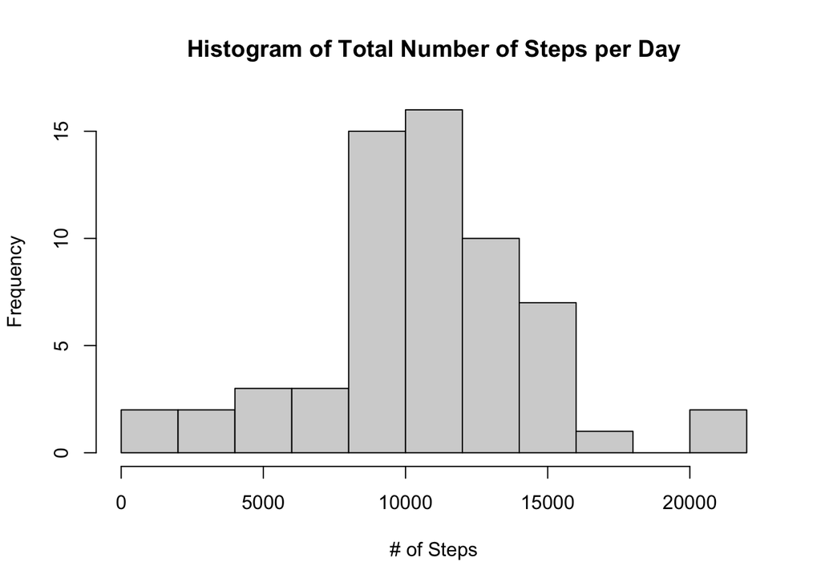

```r
new_data <- replace(data, is.na(data), avg_overall)

new_steps <- aggregate(x=new_data$steps, FUN = sum, by = list(new_data$date))
new_steps <- new_steps[complete.cases(total_steps),]
colnames(new_steps) <- c("Date","Total Steps")

hist(new_steps$`Total Steps`,breaks = 10, xlab = "# of Steps",
     main = "Histogram of Total Number of Steps per Day")
```

```r
mean(new_steps$`Total Steps`)
```

[1] 10581.01

```r
median(new_steps$`Total Steps`)
```

[1] 10395

Finally, we are going to compare activity on the weekdays compared to the weekend. First, we’ll create a factor variable determining if the day is either a weekday or a weekend.

```r
new_data$date <- as.Date(new_data$date)
new_data$weekdayType <- ifelse(weekdays(new_data$date) %in% c("Satuday", "Sunday"),"weekend", "weekday")
```

And then to visualize the data, we are going to create a panel plot with the average steps per interval plotted with respect to the type of day

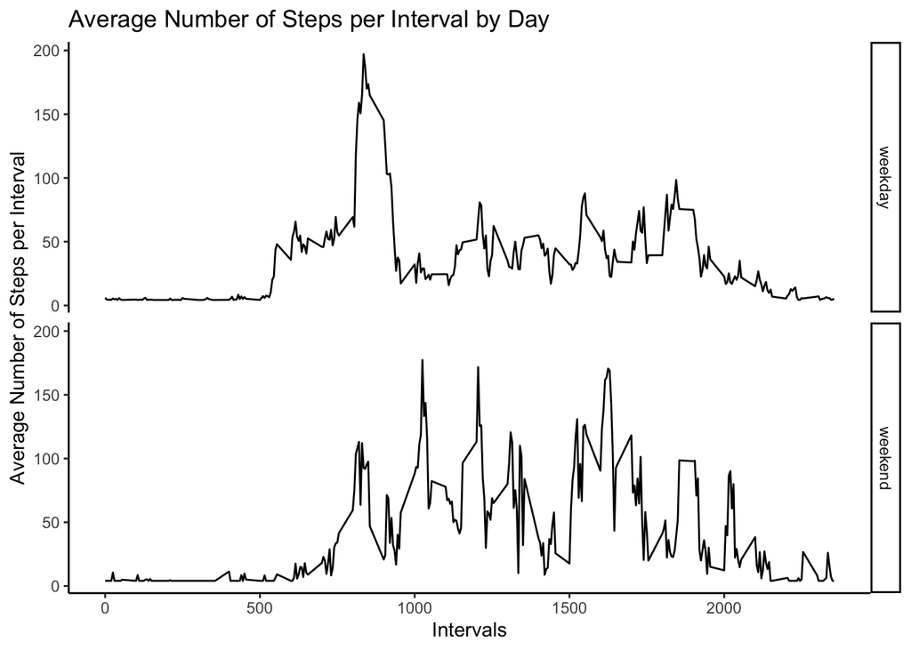

```r
new_interval <- aggregate(x=new_data$steps, FUN = mean, by = list(new_data$interval,new_data$weekdayType))
colnames(new_interval) <- c("Interval","DayType","Average Steps")
ggplot(data = new_interval, aes(Interval, `Average Steps`)) + geom_line() +
        facet_grid(DayType ~ .) + xlab("Intervals") +
        ylab("Average Number of Steps per Interval") +
        ggtitle("Average Number of Steps per Interval by Day") + theme_classic()
```

As one can see, there seems to be quite a difference in activity between the weekdays and the weekend.